# Eskom 2023 Parser Report

This notebook reads the canonical module 02 CSV outputs and summarizes the parser repair, timestamp filter, target anchors, and accounting checks used by the South Africa fixed-validation workflow.

```python
from __future__ import annotations

import os
from pathlib import Path

os.environ.setdefault("MPLCONFIGDIR", "/private/tmp/pypsa-earth-matplotlib")

import matplotlib.pyplot as plt
import pandas as pd
from IPython.display import display

ROOT = Path.cwd()
if not (ROOT / "data").exists():
    ROOT = Path.cwd().parents[2]

HOURLY = ROOT / "data/za_validation/eskom_2023_hourly_clean.csv"
TARGETS = ROOT / "data/za_validation/eskom_2023_targets_by_carrier.csv"
REPORT = ROOT / "data/za_audit/eskom_2023_parser_report.csv"

hourly = pd.read_csv(HOURLY, parse_dates=["Date Time Hour Beginning"])
targets = pd.read_csv(TARGETS)
report = pd.read_csv(REPORT)

{
    "hourly_rows": len(hourly),
    "targets": len(targets),
    "report_checks": len(report),
    "start": hourly["Date Time Hour Beginning"].min(),
    "end": hourly["Date Time Hour Beginning"].max(),
}
```

```
{'hourly_rows': 8760,
 'targets': 30,
 'report_checks': 19,
 'start': Timestamp('2023-01-01 00:00:00'),
 'end': Timestamp('2023-12-31 23:00:00')}
```

## Column Inspection

The parser stores the raw header list in `data/za_audit/eskom_2023_parser_report.csv`. These columns are the basis for the resolved accounting identity.

```python
header_value = report.loc[report["check_id"].eq("raw-column-headers"), "value"].iloc[0]
headers = header_value.split(" | ")
pd.DataFrame({"position": range(len(headers)), "column": headers})
```

|  | position | column |
| --- | --- | --- |
| 0 | 0 | Date Time Hour Beginning |
| 1 | 1 | Original Res Forecast before Lockdown |
| 2 | 2 | Residual Forecast |
| 3 | 3 | RSA Contracted Forecast |
| 4 | 4 | Dispatchable Generation |
| 5 | 5 | Residual Demand |
| 6 | 6 | RSA Contracted Demand |
| 7 | 7 | International Exports |
| 8 | 8 | International Imports |
| 9 | 9 | Thermal Generation |
| 10 | 10 | Nuclear Generation |
| 11 | 11 | Eskom Gas Generation |
| 12 | 12 | Eskom OCGT Generation |
| 13 | 13 | Hydro Water Generation |
| 14 | 14 | Pumped Water Generation |
| 15 | 15 | ILS Usage |
| 16 | 16 | Manual Load_Reduction(MLR) |
| 17 | 17 | IOS Excl ILS and MLR |
| 18 | 18 | Dispatchable IPP OCGT |
| 19 | 19 | Eskom Gas SCO |
| 20 | 20 | Eskom OCGT SCO |
| 21 | 21 | Hydro Water SCO |
| 22 | 22 | Pumped Water SCO Pumping |
| 23 | 23 | Wind |
| 24 | 24 | PV |
| 25 | 25 | CSP |
| 26 | 26 | Other RE |
| 27 | 27 | Total RE |
| 28 | 28 | Wind Installed Capacity |
| 29 | 29 | PV Installed Capacity |
| 30 | 30 | CSP Installed Capacity |
| 31 | 31 | Other RE Installed Capacity |
| 32 | 32 | Total RE Installed Capacity |
| 33 | 33 | Installed Eskom Capacity |
| 34 | 34 | Total PCLF |
| 35 | 35 | Total UCLF |
| 36 | 36 | Total OCLF |
| 37 | 37 | Total UCLF+OCLF |
| 38 | 38 | Non Comm Sentout |
| 39 | 39 | Drakensberg Gen Unit Hours |
| 40 | 40 | Palmiet Gen Unit Hours |
| 41 | 41 | Ingula Gen Unit Hours |

## Parser Accounting

Rows with a split `Total UCLF+OCLF` comma decimal are repaired before numeric parsing. The 2023 slice must contain exactly 8,760 hourly observations.

```python
parser_checks = report[report["category"].isin(["parser", "filter", "schema", "provenance"])]
display(parser_checks[["check_id", "status", "value", "unit", "notes"]])

assert len(hourly) == 8760
assert hourly["Date Time Hour Beginning"].is_unique
assert hourly["Date Time Hour Beginning"].min() == pd.Timestamp("2023-01-01 00:00")
assert hourly["Date Time Hour Beginning"].max() == pd.Timestamp("2023-12-31 23:00")
```

|  | check_id | status | value | unit | notes |
| --- | --- | --- | --- | --- | --- |
| 0 | raw-input-path | pass | data/za_audit/raw/eskom_data_2023_full.csv | NaN | canonical staged Eskom raw CSV |
| 1 | raw-input-sha256 | pass | 8c2220f114ba60d5ae823f5116368cc2a664ec625d70f4... | NaN | hash of staged raw CSV |
| 2 | raw-column-count | pass | 42 | NaN | header column count |
| 3 | raw-column-headers | pass | Date Time Hour Beginning \| Original Res Foreca... | NaN | printed for accounting identity inspection |
| 4 | raw-row-count | pass | 10272 | rows | NaN |
| 5 | exact-row-count | pass | 9 | rows | NaN |
| 6 | repaired-row-count | pass | 10263 | rows | rows repaired for split Total UCLF+OCLF comma ... |
| 7 | bad-field-count-rows | pass | 0 | rows | NaN |
| 8 | pre-2023-rows-dropped | pass | 744 | rows | NaN |
| 9 | post-2023-rows-dropped | pass | 768 | rows | NaN |
| 10 | clean-hourly-row-count | pass | 8760 | rows | exactly 8760 hourly observations |
| 11 | clean-start | pass | 2023-01-01 00:00:00 | NaN | NaN |
| 12 | clean-end | pass | 2023-12-31 23:00:00 | NaN | NaN |
| 13 | required-numeric-columns | pass | 28 | columns | RSA Contracted Demand, Residual Demand, Dispat... |

## Accounting Checks

The resolved identity is `Residual Demand = Dispatchable Generation + Manual Load_Reduction(MLR) + ILS Usage + IOS Excl ILS and MLR`. `RSA Contracted Demand - Residual Demand - Total RE` is retained as a source discrepancy warning.

```python
accounting = report[report["category"].eq("accounting")]
display(accounting[["check_id", "status", "value", "unit", "tolerance", "notes"]])

blocking_failures = accounting[accounting["status"].eq("fail")]
assert blocking_failures.empty
```

|  | check_id | status | value | unit | tolerance | notes |
| --- | --- | --- | --- | --- | --- | --- |
| 14 | total-re-hourly-identity | pass | 9.094947017729282e-13 | MW | 0.001000 | Total RE = Wind + PV + CSP + Other RE |
| 15 | residual-demand-hourly-identity | pass | 0.0010000000038417056 | MW | 0.001000 | Residual Demand = Dispatchable Generation + ML... |
| 16 | residual-demand-annual-identity | pass | -1.4200000025812188e-07 | TWh | 0.000001 | annual residual-demand identity difference |
| 17 | rsa-contracted-demand-identity | warn | 0.444123395 | TWh | 0.000001 | RSA Contracted Demand - Residual Demand - Tota... |

## Annual Targets

Energy targets are annual TWh totals computed from hourly MW averages. Capacity targets use the end-of-year 2023 value where later validation needs one reference capacity.

```python
display(targets[["target", "value", "unit", "status", "source", "notes"]])

required_targets = {
    "RSA Contracted Demand",
    "Residual Demand",
    "Dispatchable Generation",
    "Manual Load Reduction",
    "ILS Usage",
    "IOS Excl ILS and MLR",
    "MLR + ILS + IOS",
    "International Imports",
    "International Exports",
    "Eskom Gas Generation",
}
missing = required_targets.difference(set(targets["target"]))
assert not missing, missing
```

|  | target | value | unit | status | source | notes |
| --- | --- | --- | --- | --- | --- | --- |
| 0 | RSA Contracted Demand | 225.874862 | TWh | pass | Eskom 2023 raw data; external primary cross-ch... | raw 2023 hourly MW average summed and converte... |
| 1 | Residual Demand | 207.189536 | TWh | pass | Eskom 2023 raw data | raw 2023 hourly MW average summed and converte... |
| 2 | Dispatchable Generation | 190.434230 | TWh | pass | Eskom 2023 raw data | raw 2023 hourly MW average summed and converte... |
| 3 | Thermal Generation | 165.626914 | TWh | pass | Eskom 2023 raw data | raw 2023 hourly MW average summed and converte... |
| 4 | Nuclear Generation | 8.126616 | TWh | pass | Eskom 2023 raw data; CSIR Utility Statistics R... | raw 2023 hourly MW average summed and converte... |
| 5 | Eskom Gas Generation | 0.007118 | TWh | warn | Eskom 2023 raw data | raw 2023 hourly MW average summed and converte... |
| 6 | Eskom OCGT Generation | 3.566287 | TWh | pass | Eskom 2023 raw data | raw 2023 hourly MW average summed and converte... |
| 7 | Dispatchable IPP OCGT | 1.676847 | TWh | pass | Eskom 2023 raw data | raw 2023 hourly MW average summed and converte... |
| 8 | Hydro Water Generation | 1.991805 | TWh | pass | Eskom 2023 raw data | raw 2023 hourly MW average summed and converte... |
| 9 | Pumped Water Generation | 4.294481 | TWh | pass | Eskom 2023 raw data | raw 2023 hourly MW average summed and converte... |
| 10 | Pumped Water SCO Pumping | -5.657906 | TWh | pass | Eskom 2023 raw data; negative value is energy ... | raw 2023 hourly MW average summed and converte... |
| 11 | Wind | 11.613364 | TWh | pass | Eskom 2023 raw data; CSIR Utility Statistics R... | raw 2023 hourly MW average summed and converte... |
| 12 | PV | 5.014845 | TWh | pass | Eskom 2023 raw data; CSIR Utility Statistics R... | raw 2023 hourly MW average summed and converte... |
| 13 | CSP | 1.375349 | TWh | pass | Eskom 2023 raw data; CSIR Utility Statistics R... | raw 2023 hourly MW average summed and converte... |
| 14 | Other RE | 0.237645 | TWh | pass | Eskom 2023 raw data | raw 2023 hourly MW average summed and converte... |
| 15 | Total RE | 18.241202 | TWh | pass | Computed from Eskom raw data; equals Wind + PV... | raw 2023 hourly MW average summed and converte... |
| 16 | Manual Load Reduction | 16.561840 | TWh | pass | Eskom 2023 raw data | raw 2023 hourly MW average summed and converte... |
| 17 | ILS Usage | 0.073166 | TWh | pass | Eskom 2023 raw data | raw 2023 hourly MW average summed and converte... |
| 18 | IOS Excl ILS and MLR | 0.120301 | TWh | pass | Eskom 2023 raw data | raw 2023 hourly MW average summed and converte... |
| 19 | International Imports | 10.841730 | TWh | pass | Eskom 2023 raw data | raw 2023 hourly MW average summed and converte... |
| 20 | International Exports | 11.250298 | TWh | pass | Eskom 2023 raw data | raw 2023 hourly MW average summed and converte... |
| 21 | MLR + ILS + IOS | 16.755307 | TWh | pass | Computed from Eskom 2023 raw data | observed reduced/unserved demand proxy for val... |
| 22 | Wind installed capacity | 3442.570000 | MW | pass | Eskom 2023 raw data; CSIR Utility Statistics R... | capacity anchor for later validation modules |
| 23 | PV installed capacity start | 2212.090000 | MW | pass | Eskom 2023 raw data; start-of-year value | capacity anchor for later validation modules |
| 24 | PV installed capacity end | 2287.090000 | MW | pass | Eskom 2023 raw data; end-of-year value used fo... | capacity anchor for later validation modules |
| 25 | CSP installed capacity | 500.000000 | MW | pass | Eskom 2023 raw data; CSIR Utility Statistics R... | capacity anchor for later validation modules |
| 26 | Other RE installed capacity | 50.580000 | MW | pass | Eskom 2023 raw data; external primary cross-ch... | capacity anchor for later validation modules |
| 27 | Total RE installed capacity start | 6205.240000 | MW | pass | Eskom 2023 raw data; start-of-year value | capacity anchor for later validation modules |
| 28 | Total RE installed capacity end | 6280.240000 | MW | pass | Eskom 2023 raw data; end-of-year value used fo... | capacity anchor for later validation modules |
| 29 | Installed Eskom Capacity | 46686.000000 | MW | pass | Eskom 2023 raw data; Eskom Annual Report 2023 ... | capacity anchor for later validation modules |

## Time-Series View

The plots below provide a fast visual check that demand, renewable generation, and reduced/unserved-demand components are in the expected order of magnitude.

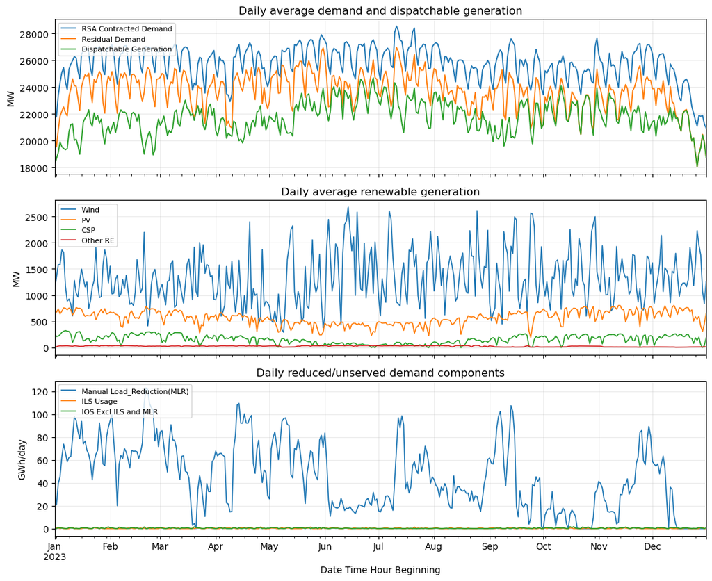

```python
plot_df = hourly.set_index("Date Time Hour Beginning")
daily = plot_df.resample("D").mean()
daily_reduced = plot_df[["Manual Load_Reduction(MLR)", "ILS Usage", "IOS Excl ILS and MLR"]].resample("D").sum() / 1000

fig, axes = plt.subplots(3, 1, figsize=(11, 9), sharex=True)
daily[["RSA Contracted Demand", "Residual Demand", "Dispatchable Generation"]].plot(ax=axes[0], linewidth=1.3)
axes[0].set_ylabel("MW")
axes[0].set_title("Daily average demand and dispatchable generation")

daily[["Wind", "PV", "CSP", "Other RE"]].plot(ax=axes[1], linewidth=1.2)
axes[1].set_ylabel("MW")
axes[1].set_title("Daily average renewable generation")

daily_reduced.plot(ax=axes[2], linewidth=1.2)
axes[2].set_ylabel("GWh/day")
axes[2].set_title("Daily reduced/unserved demand components")

for ax in axes:
    ax.grid(True, alpha=0.25)
    ax.legend(loc="upper left", fontsize=8)

fig.tight_layout()
plt.show()
```

## Status

Module 02 parser outputs are valid when the row-count assertions pass, accounting checks have no `fail` rows, and the only expected accounting warning is the retained `RSA Contracted Demand - Residual Demand - Total RE` discrepancy.